# Ridge Regression

Elara

2016年5月5日

# 算法

最小化
$$\sum_i (y_i-x_i^{T}\beta)^{2}+\lambda \sum_{j=1}^{p} \beta_j^{2}$$
解为
$$\hat{\beta}=(X^{T}X+\lambda I)^{-1}X^{T}y$$
接近0，解和OLS一样 接近无穷大，解接近0 如果是正交（orthonormal design matrix）相当于
$$\hat{\beta}_{J}^{ridge}=\frac{\hat{\beta}_{J}^{OLS}}{1+\lambda}$$
岭回归的作用是*shrinkage* 收缩 估计量有偏但是极大减小了估计量方差

# 代码

```r
library("MASS")
library("ggplot2")
#生成具有相关性的3组数据模拟多重共线性
x1 <- rnorm(20)
x2 <- rnorm(20,mean=x1,sd=.01)
y <- rnorm(20,mean=3+x1+x2)
#普通LM回归的OLS系数
lm(y~x1+x2)$coef
```

```
## (Intercept)          x1          x2
##   3.1181501  -0.2273058   1.9929718
```

```r
#岭回归,$\lambda$ =1
lm.ridge(y~x1+x2,lambda=1)
```

```
##                  x1        x2
## 3.1341852 0.8594170 0.8623238
```

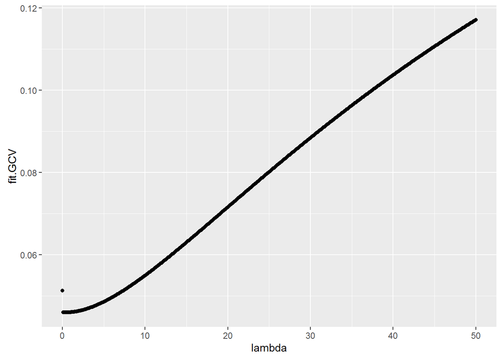

```r
#岭回归,$\lambda$ =0到50并求GCV准则与$\lambda$关系图像
lambda <- seq(0,50,by=0.1)
fit <- lm.ridge(y~x1+x2, lambda=seq(0,50,by=0.1))
m <- data.frame(lambda,fit$GCV)
p <- ggplot(data=m,aes(x=lambda,y=fit.GCV))
p+geom_point()
```

OLS回归结果不一定存在，如果X不是满秩，$X^{T}X$ 不可逆，没有OLS的唯一解  
在岭回归中这个问题不存在,因为有个推论$X^{T}X+\lambda I$ 总是可逆（不论X是什么矩阵），所以岭回归的解总是唯一的

# 方差与偏差

岭回归的估计量的方差
$$Var(\hat{\beta})=\sigma ^{2}WX^{T}XW$$
, 其中
$$W=(X^{T}X+\lambda I)^{-1}$$

岭回归的估计连的偏差
$$Bias(\hat{\beta})=-\lambda W\beta$$

可以证明总方差$\sum_j Var(\hat{\beta}_{j})$ 是一个对$\lambda$ 单调递减的序列  
总偏差$\sum_j Bias^{2}(\hat{\beta})$ 是一个对$\lambda$ 单调递增的序列

永远存在一个$\lambda$ 使得$\hat{\beta}_{J}^{ridge}$ 的MSE比 $\hat{\beta}_{J}^{OLS}$ 的小

一个激进的结论：就算我们的模型是完全正确并且服从我们设定的分布，我们仍然可以总是通过shrinking towards zero来获得一个更好的估计量（MSE更小）

# 贝叶斯结论

如果$\beta ~N(0,\tau^{2}I)$ 那么$\beta$ 的后验均值（posterior mean）是
$$(X^{T}X+\frac{\sigma^{2}}{\tau^{2}} I)^{-1}X^{T}y$$

# $\lambda$ 的选择

## 估计自由度-信息准则

对于$\hat{y}=Hy$，那么tr(H)=p 自由度
那么
$$H_{ridge} =(X^{T}X+\lambda I)^{-1}X^{T}$$
所以自由度为tr($H_{ridge}$)
可以证明自由度
$$df_{ridge} = \sum \frac{\lambda_i}{\lambda_i+\lambda}$$
其中$\lambda_i$ 是$X^{T}X$ 的特征值

重点：df对$\lambda$ 递减，df=p的时候$\lambda$=0，df=0的时候$\lambda$ 正无穷

# 自由度选择-交叉验证（cross-validation）

AIC=nlog(RSS)+2df  
BIC=nlog(RSS)+dflog(n)

重复拟合-会过度 增加数据集用来训练不现实  
分离数据集作为训练和验证集数据量不够

交叉验证：把数据分成K份，用K-1份做fit，最后一份用来评估  
对所有数据都重复操作，用平均评估做结果  
如果选择分成n份–leave-one-out corss-validation

GVC，AIC BIC准则